# Fruits Classification

This task intends to measure your deep learning basic skills. We will provide you a dataset containing 131 different fruits. Download it from this [link](https:///www.kaggle.com/moltean/fruits), download it and upload it to your copy of this file

You have to implement a Convolutional Neural Network to classify the input fruit image. For this task, you must follow the following rules:

- Use a ResNet50 as your CNN backbone.
- The model output must be a probability score for all the classes.
- You can implement the model in any Deep Learning framework that you are used to use.
- Make sure you write your code following the best practices.
- Make sure you document all the steps you took to solve the problem.

```python
%cd /kaggle/input/fruits
!ls
```

```
/kaggle/input/fruits
fruits-360
```

```python
# Load and transform the dataset
import os

from torchvision.datasets import ImageFolder
from torchvision.transforms import transforms, ToTensor
from torch.utils.data import random_split, DataLoader

# Train the model
import copy
import time

import torch
import torch.nn as nn
from torchvision import models

# Evaluate the model
import seaborn as sns
import matplotlib.pyplot as plt
from sklearn.metrics import confusion_matrix, classification_report

# Apply the model
from random import choice

import torch.nn.functional as nnf
```

## Loading the dataset

- Load and transform the dataset
- Split the training data into training and validation
- Get the dataset classes
- Create Dataloaders with the datasets

```python
train_directory = './fruits-360/Training'
test_directory = './fruits-360/Test'

transform = transforms.Compose([
    transforms.Resize([224, 224]),  # 224x224 is image size used in pre-trained models
    transforms.ToTensor()
])


train_dataset = ImageFolder(train_directory, transform=transform)
print('Training dataset size:', len(train_dataset))
test_dataset = ImageFolder(test_directory, transform=transform)
print('Test dataset size:', len(test_dataset))
```

```
Training dataset size: 67692
Test dataset size: 22688
```

```python
# Split training and validation data
validation_size = int(0.1 * len(train_dataset))  # Validation represents 10% of the training data
training_size = len(train_dataset) - validation_size

train_dataset, validation_dataset = random_split(train_dataset,
                                                 [training_size, validation_size])
len(train_dataset), len(validation_dataset)
```

```
(60923, 6769)
```

```python
# Get dataset classes
classes = os.listdir(train_directory)

len(classes)
```

```
131
```

```python
# Create data loaders from datasets
batch_size = 32

training_loader = DataLoader(dataset=train_dataset, batch_size=batch_size, shuffle=True)
test_loader = DataLoader(dataset=test_dataset, batch_size=batch_size, shuffle=False)
validation_loader = DataLoader(dataset=validation_dataset, batch_size=batch_size, shuffle=False)
```

## Training the model

- Implement the train and evaluation steps
- Implement the model training function
- Load ResNet50 as backbone model
- Set hyperparameters and model operations
- Train the model

```python
device =  torch.device("cuda:0" if torch.cuda.is_available() else "cpu")


def training_step(model, criterion, optimizer, dataloader_train):
    running_loss = 0.0

    # Iterate over data.
    for inputs, labels in dataloader_train:
        inputs = inputs.to(device)
        labels = labels.to(device)

        # Zero the parameter gradients
        optimizer.zero_grad()

        with torch.set_grad_enabled(True):
            outputs = model(inputs)
            loss = criterion(outputs, labels)

            loss.backward()
            optimizer.step()

        running_loss += loss.item()

    return running_loss


def evaluation_step(model, criterion, optimizer, dataloader_val):
    running_loss = 0.0
    running_corrects = 0

    # Iterate over data.
    for inputs, labels in dataloader_val:
        inputs = inputs.to(device)
        labels = labels.to(device)

        outputs = model(inputs)
        loss = criterion(outputs, labels)

        running_loss += loss.item()
        _, preds = torch.max(outputs, 1)
        running_corrects += torch.sum(preds == labels.data)

    return running_loss, running_corrects


def train_model(model, criterion, optimizer, scheduler, num_epochs=5):
    history = {
        'train_loss': list(),
        'validation_loss': list(),
        'validation_accuracy': list()
    }

    since = time.time()

    best_model = copy.deepcopy(model.state_dict())
    best_accuracy = 0.0

    for epoch in range(num_epochs):
        print(f'Epoch {epoch}/{num_epochs - 1}')
        print('-' * 10)

        # Training step
        model.train()

        running_loss = training_step(
            model, criterion, optimizer, training_loader
        )

        train_epoch_loss = running_loss / len(training_loader.dataset)

        scheduler.step()

        # Evaluation step
        model.eval()

        running_loss, running_corrects = evaluation_step(
            model, criterion, optimizer, validation_loader
        )

        validation_epoch_loss = running_loss / len(validation_loader.dataset)
        epoch_accuracy = running_corrects.double() / len(validation_loader.dataset)

        print(f'Training Loss: {train_epoch_loss:.4f} '
            + f'Validation Loss: {validation_epoch_loss:.4f} '
            + f'Accuracy: {epoch_accuracy:.4f}\n')

        history['train_loss'].append(train_epoch_loss)
        history['validation_loss'].append(validation_epoch_loss)
        history['validation_accuracy'].append(epoch_accuracy)

        # Deep copy the model if it presents the best accuracy
        if epoch_accuracy > best_accuracy:
            best_accuracy = epoch_accuracy
            best_model = copy.deepcopy(model.state_dict())

    time_elapsed = time.time() - since
    minutes = time_elapsed // 60
    seconds = time_elapsed % 60

    print(f'Training complete in {minutes:.0f}m {seconds:.0f}s')
    print(f'Best accuracy: {best_accuracy:4f}')

    # Load best model weights
    model.load_state_dict(best_model)
    return model, history


device
```

```
device(type='cuda', index=0)
```

```python
# Load ResNet50 as backbone
model_base = models.resnet50(pretrained=True)
num_features = model_base.fc.in_features
model_base.fc = nn.Linear(num_features, len(classes))

# Load model to GPU
model_base.to(device)

# Hyper-parameters
step_size  = 7
gamma = 0.1

criterion = nn.CrossEntropyLoss()
optimizer_ft = torch.optim.Adam(model_base.parameters())
scheduler = torch.optim.lr_scheduler.StepLR(optimizer_ft, step_size=step_size, gamma=gamma)
```

```
Downloading: "https://download.pytorch.org/models/resnet50-19c8e357.pth" to /root/.cache/torch/hub/checkpoints/resnet50-19c8e357.pth
```

```python
model, history = train_model(model_base, criterion, optimizer_ft, scheduler, num_epochs=3)
```

[output not shown]

## Evaluating the model

- Plot the model accuracyand loss over the epochs
- Measure the model accuracy for the test dataset
- Assess the dataset classes for each evalution metric
- Plot the heatmap with the results

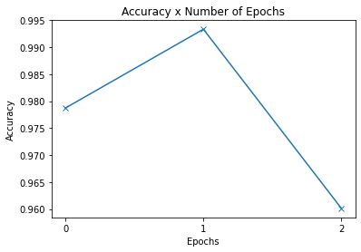

```python
def plot_accuracy(history):
    accuracy = history["validation_accuracy"]
    epochs = range(len(accuracy))

    plt.plot(accuracy, "-x")
    plt.xticks(epochs)

    plt.title("Accuracy x Number of Epochs")
    plt.xlabel("Epochs")
    plt.ylabel("Accuracy")


plot_accuracy(history)
```

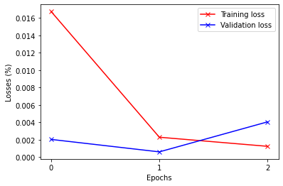

```python
def plot_losses(history):
    train_loss = history["train_loss"]
    validation_loss = history["validation_loss"]
    epochs = range(len(train_loss))

    plt.plot(train_loss, "-rx")  # r = Red
    plt.plot(validation_loss, "-bx")  # b = Blue
    plt.xticks(epochs)

    plt.legend(["Training loss", "Validation loss"])
    plt.xlabel("Epochs")
    plt.ylabel("Losses (%)")


plot_losses(history)
```

```python
def evaluate(model, data_loader):
    correct_predictions = 0.0
    model.eval()
    y_hat = list()
    y_true = list()

    for (inputs, labels) in data_loader:
        inputs = inputs.to(device)
        labels = labels.to(device)

        outputs = model(inputs)
        _, preds = torch.max(outputs, 1)

        y_hat.append(preds)
        correct_predictions += torch.sum(preds == labels.data)

    accuracy = correct_predictions.double() / len(data_loader.dataset)
    return accuracy, y_true, y_hat


accuracy, y_true, y_hat = evaluate(model, test_loader)
print(f'Accuracy: {accuracy:.4f}')
```

```
Accuracy: 0.9819
```

```
                     precision    recall  f1-score   support

             Quince       0.93      1.00      0.96       164
   Grapefruit White       0.99      1.00      1.00       148
         Granadilla       1.00      1.00      1.00       160
             Orange       1.00      1.00      1.00       164
        Apple Red 3       1.00      1.00      1.00       161
      Grape White 2       1.00      1.00      1.00       164
          Corn Husk       1.00      1.00      1.00       152
          Tamarillo       1.00      1.00      1.00       164
         Banana Red       1.00      0.96      0.98       164
     Nectarine Flat       1.00      1.00      1.00       144
      Pepper Yellow       0.96      1.00      0.98       166
         Nut Forest       1.00      1.00      1.00       164
       Pear Monster       1.00      1.00      1.00       219
                Fig       1.00      1.00      1.00       164
       Tomato Heart       1.00      1.00      1.00       143
   Onion Red Peeled       1.00      1.00      1.00       166
        Lemon Meyer       1.00      1.00      1.00       166
          Onion Red       1.00      1.00      1.00       152
      Passion Fruit       0.92      1.00      0.96       166
      Cucumber Ripe       1.00      0.93      0.96       150
       Cactus fruit       1.00      1.00      1.00       154
 Tomato not Ripened       1.00      1.00      1.00       166
          Mango Red       1.00      1.00      1.00       164
    Apple Pink Lady       1.00      0.99      1.00       164
        Pomegranate       1.00      0.94      0.97       166
               Plum       1.00      1.00      1.00       234
          Pineapple       1.00      1.00      1.00       164
           Tomato 1       0.95      1.00      0.97       246
           Cherry 2       1.00      1.00      1.00       246
        Apple Red 2       1.00      1.00      1.00       164
       Avocado ripe       1.00      1.00      1.00       164
              Dates       0.78      1.00      0.88       164
           Maracuja       0.95      0.95      0.95       153
             Papaya       1.00      1.00      1.00       166
          Nut Pecan       0.87      1.00      0.93       166
         Pear Stone       0.99      0.88      0.93       150
  Cherry Wax Yellow       1.00      0.66      0.80       154
           Eggplant       1.00      1.00      1.00       130
```

[output cut: 82 more lines]

```
               Corn       1.00      1.00      1.00       246
      Grape White 3       1.00      1.00      1.00       225
 Apple Red Yellow 1       1.00      1.00      1.00       246
         Grape Pink       1.00      1.00      1.00       160
             Banana       1.00      1.00      1.00       164
      Grape White 4       1.00      0.98      0.99       228
           Kohlrabi       0.97      1.00      0.98       127
       Pepper Green       1.00      1.00      1.00       153
         Watermelon       1.00      0.78      0.88       158
              Mango       1.00      1.00      1.00       249
           Tomato 2       0.99      1.00      0.99       157

           accuracy                           0.98     22688
          macro avg       0.99      0.98      0.98     22688
       weighted avg       0.98      0.98      0.98     22688
```

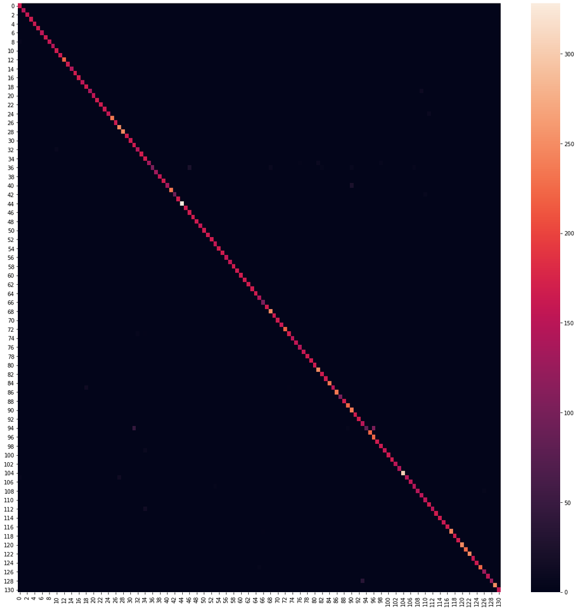

```python
def evaluate_classes(data_loader, y_true, y_hat):
    Y_true = list()
    Y_hat = list()

    for inputs, labels in iter(data_loader):
        for y_true in labels.cpu().numpy():
            Y_true.append(y_true)

    for joint in y_hat:
        for label in joint.cpu().numpy():
            Y_hat.append(label)

    report = classification_report(Y_true, Y_hat, target_names=classes, zero_division=0)
    plt.rcParams["figure.figsize"] = (20,20)

    sns.heatmap(confusion_matrix(Y_true, Y_hat))

    return report


report = evaluate_classes(test_loader, y_true, y_hat)
print(report)
```

## Applying the model

- Randomly select and classify images from the test dataset
- Model output is presented as a probability score for all classes

```python
def predict(image_input, model):
    image = image_input.unsqueeze(0).to(device)
    output = model(image)

    probabilities = nnf.softmax(output, dim=1)[0]

    probabilities_classes = [
        (classes[index], probability) for index, probability in enumerate(probabilities)
    ]

    # Order dict by highest probability
    ordered_probabilities = sorted(
        probabilities_classes,
        key=lambda probability_class: probability_class[1],
        reverse=True
    )

    return ordered_probabilities
```

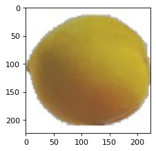

```
Label: Apple Crimson Snow

Probability scores
Apple Crimson Snow             1.0000
Dates                          0.0000
Potato Red Washed              0.0000
Lychee                         0.0000
Cantaloupe 2                   0.0000
Kaki                           0.0000
Blueberry                      0.0000
Lemon Meyer                    0.0000
Pear Stone                     0.0000
Limes                          0.0000
Apple Golden 2                 0.0000
Apple Red Yellow 2             0.0000
Tomato not Ripened             0.0000
Corn Husk                      0.0000
Pomegranate                    0.0000
Banana Red                     0.0000
Tangelo                        0.0000
Plum 3                         0.0000
Pepino                         0.0000
Pear Monster                   0.0000
Physalis with Husk             0.0000
Peach 2                        0.0000
Strawberry Wedge               0.0000
Nectarine                      0.0000
Kohlrabi                       0.0000
Cherry Wax Black               0.0000
Grapefruit Pink                0.0000
Apple Braeburn                 0.0000
Grape Blue                     0.0000
Granadilla                     0.0000
Grape White 3                  0.0000
Pear Abate                     0.0000
Potato Red                     0.0000
Banana Lady Finger             0.0000
Orange                         0.0000
Peach Flat                     0.0000
Carambula                      0.0000
```

[output cut: 79 more lines]

```
Cactus fruit                   0.0000
Apple Red 2                    0.0000
Huckleberry                    0.0000
Cucumber Ripe                  0.0000
Apple Golden 3                 0.0000
Quince                         0.0000
Grapefruit White               0.0000
Passion Fruit                  0.0000
Pomelo Sweetie                 0.0000
Apple Golden 1                 0.0000
Grape White 4                  0.0000
Cherry Wax Yellow              0.0000
Tomato Yellow                  0.0000
Papaya                         0.0000
Tomato Heart                   0.0000
```

```python
# Randonmly chooses an image
image, label = choice(test_dataset)

# Display image and true label
plt.figure(figsize=(4, 3), dpi=80)
plt.imshow(image.permute(1,2,0))
plt.show()

print(f"Label: {classes[label]}\n")

probabilities = predict(image, model)

print("Probability scores")

for fruit_class, probability in probabilities:
    print(f"{fruit_class:30s} {probability:.4f}")
```